# Task 1: PCA for Country-Level Environmental Variables

Katherine Rosencrance

2023-02-27

# Introduction

In this report we explore several world climatic variables at a country level. These data were acquired through the use of Google Earth Engine’s publicly available remote sensing data. Final values were derived using the mean for each country at a reduction scale of 10km (zander_venter, 2018). First we will select a set of variables to analyze, then we will perform a principle component analysis visualized through a biplot and screeplot.

**Variables of Interest**

- cropland cover
- tree canopy cover
- annual rain (mean)
- annual temperature (mean)
- wind
- cloudiness

**N/A values**

Observations with N/A values were dropped from the data set before selecting the variables of interest. This lowered the number of observations from 243 to 188 values.

```r
knitr::opts_chunk$set(echo = TRUE, message = FALSE, warning = FALSE)

library(tidyverse)
library(here)
library(janitor)
library(ggfortify)
```

# Data Wrangling

```r
### read in the data
world_env <- read_csv(here("data", "world_env_vars.csv")) %>%
  clean_names() %>%
  mutate(accessibility_to_cities =
                     case_when(accessibility_to_cities <= 100 ~ "Very High",
                              accessibility_to_cities <= 500 ~ "High",
                              accessibility_to_cities <= 1000 ~ "Medium",
                              accessibility_to_cities <= 11000 ~ "Low")) %>%
  mutate(accessibility_to_cities = factor(accessibility_to_cities, levels = c('Low', 'Medium', 'High', 'Very High'))) %>%
      drop_na()
```

# PCA

```r
world_env_pca <- world_env %>%
      select(cropland_cover, tree_canopy_cover, rain_mean_annual, temp_mean_annual, wind, cloudiness) %>%
  ### rename for biplot output
    rename("cropland cover"= "cropland_cover",
         "tree canopy cover" = "tree_canopy_cover",
         "mean annual rain" = "rain_mean_annual",
         "mean annual temp" = "temp_mean_annual") %>%
  dplyr::select(where(is.numeric)) %>%
  scale() %>%
  prcomp()

### see the loadings
#world_env_pca$rotation
```

# Biplot

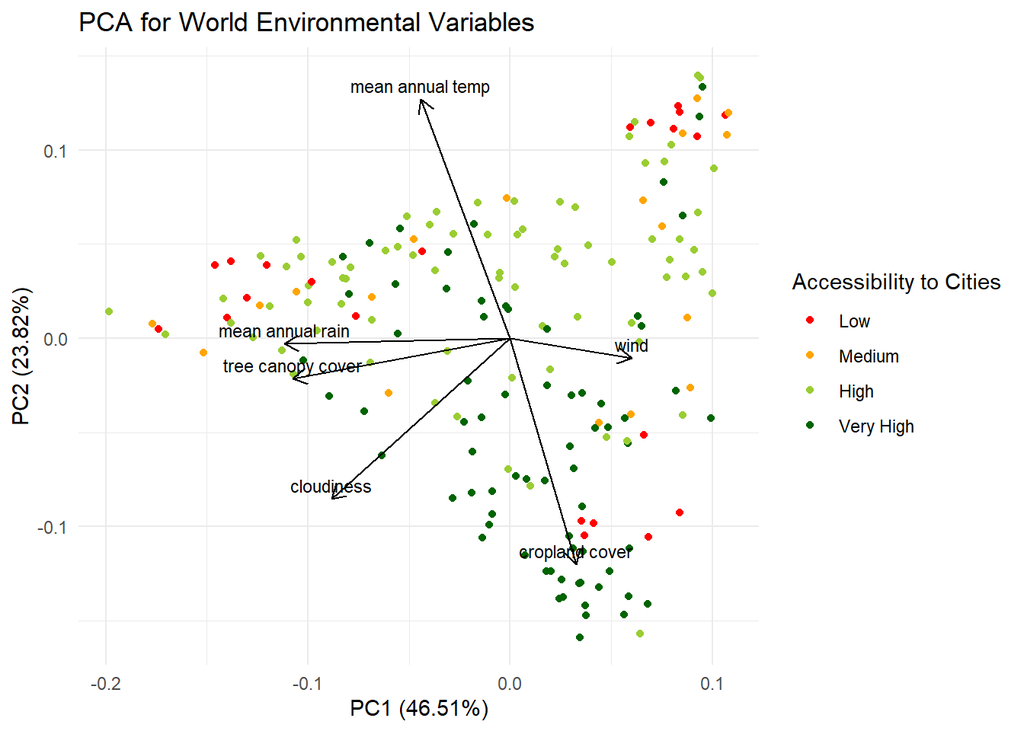

```r
autoplot(world_env_pca,
        data = world_env,
        loadings = TRUE,
        colour = 'accessibility_to_cities',
        loadings.label = TRUE,
        loadings.colour = "black",
        loadings.label.colour = "black",
        loadings.label.vjust = -0.5,
        loadings.label.size = 3
        ) +
  ggtitle("PCA for World Environmental Variables")+
  guides(color = guide_legend(title = "Accessibility to Cities"))+
  scale_color_manual(values = c('red', 'orange', 'yellowgreen', 'darkgreen')) +
  scale_fill_manual(values = c('red', 'orange', 'yellowgreen', 'darkgreen')) +
  theme_minimal()
```

**Figure 1: PCA Biplot for Country-level Environmental Variables** Biplot displaying the results of the principal component analysis (PC 1 and PC2) for each country’s selected world climate variables. Each point represents an observation based on the first two principal components, and the arrows represent the loading of variables for PC 1 and 2. Arrows point in the direction of increasing values for that variable. The color of the points represents each countries’ accessibility to cities.

# Screeplot

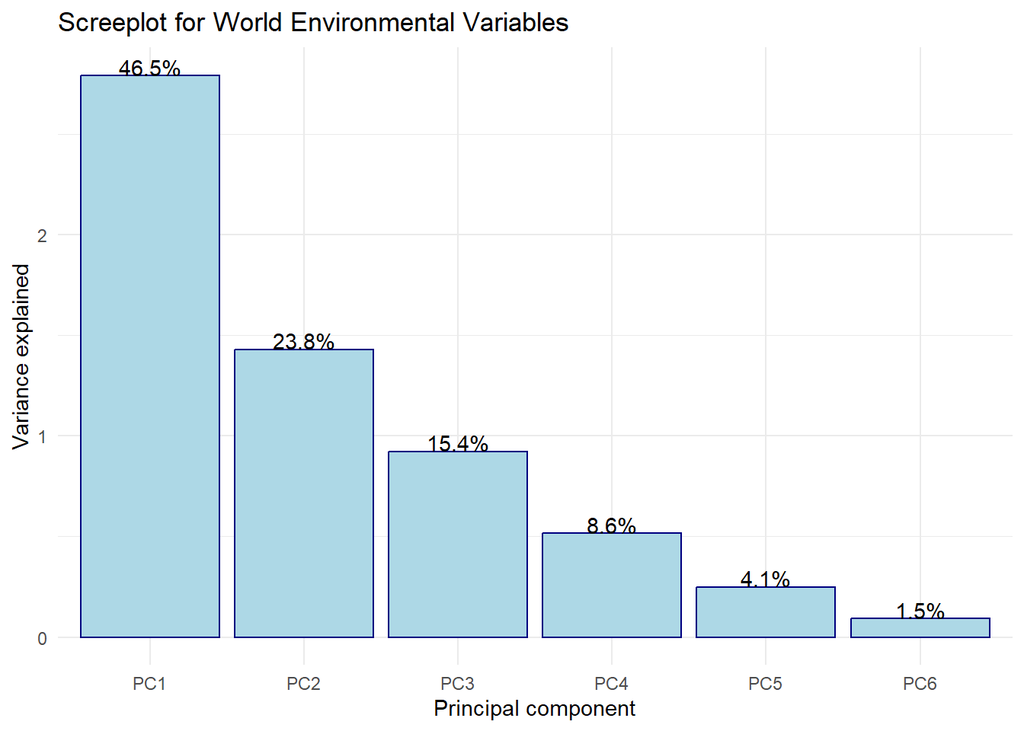

```r
sd_vec <- world_env_pca$sdev
var_vec <- sd_vec^2 ### standard deviation is sqrt of variance!
pc_names <- colnames(world_env_pca$rotation)

pct_expl_df <- data.frame(v = var_vec,
                          pct_v = var_vec / sum(var_vec),
                          pc = fct_inorder(pc_names)) %>%
  mutate(pct_lbl = paste0(round(pct_v*100, 1), '%'))

ggplot(pct_expl_df, aes(x = pc, y = v)) +
  geom_col(color = "navyblue", fill = "lightblue") +
  ggtitle("Screeplot for World Environmental Variables")+
  geom_text(aes(label = pct_lbl), vjust = 0, nudge_y = .002) +
  labs(x = 'Principal component', y = 'Variance explained')+
  theme_minimal()
```

**Figure 1: PCA Screeplot for Country-level Environmental Variables** Screeplot displaying the variance explained by each principal component for selected world climatic variables. We must include 3 principal components to explain ~85% of the variance.

# Summary

# Citation

**Data Citation:** zander_vender. 2018, Environmental variables for world countries. CC0:Public Domain. https://www.kaggle.com/datasets/zanderventer/environmental-variables-for-world-countries?select=World_countries_env_vars.csv